# M6: Data Analysis Solutions

Arvon Clemons II

10/18/2020

# 1 Part 1. Change in severity score

```r
data$change <- data$pk5 - data$pk1 #create 'change' variable
no_missing <- data %>% # remove observations with missing data
  select(pk1, pk5, change, group) %>%
  drop_na()
```

## 1.1 Numerical and Visual Summary

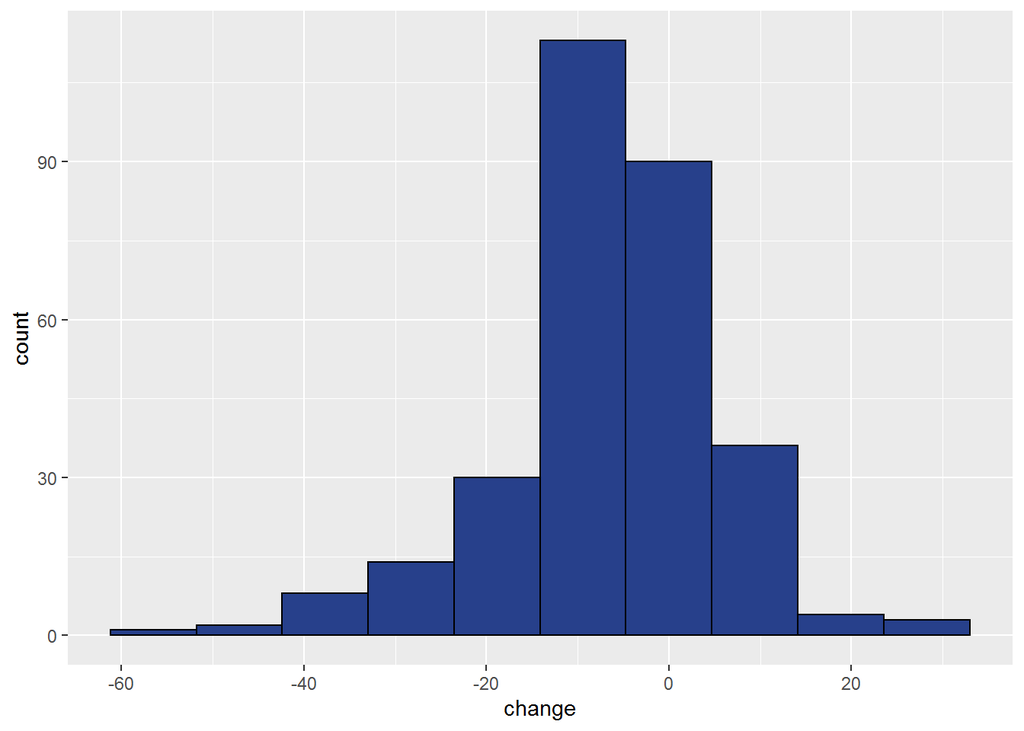

```r
# graphs
p1 <- no_missing %>%
  ggplot()
p1 + aes(x = change) +
  geom_histogram(bins = 10, colour = "black", fill = "royalblue4")
```

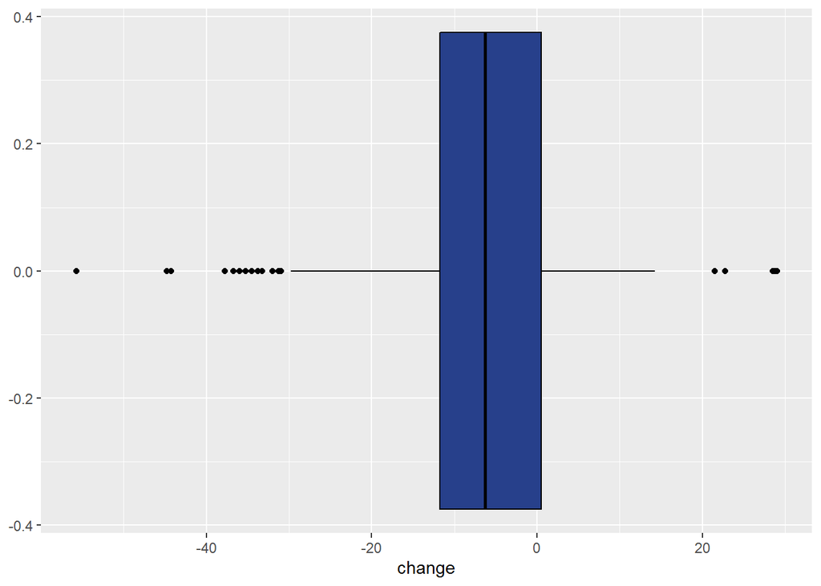

```r
p1 + aes(x = change) +
  geom_boxplot(colour = "black", fill = "royalblue4")
```

```r
# tables
knitr::kable(psych::describe(data %>% select(pk1, pk5, change) %>% drop_na(), fast = T), caption = "Difference in Headache Severity Score From Baseline to 1 Year")
```

Difference in Headache Severity Score From Baseline to 1 Year

|  | vars | n | mean | sd | min | max | range | se |
| --- | --- | --- | --- | --- | --- | --- | --- | --- |
| pk1 | 1 | 301 | 25.56894 | 15.42398 | 6.75 | 94.75 | 88.00 | 0.8890235 |
| pk5 | 2 | 301 | 19.08245 | 15.61158 | 0.00 | 87.25 | 87.25 | 0.8998366 |
| change | 3 | 301 | -6.48649 | 11.84064 | -55.75 | 29.00 | 84.75 | 0.6824832 |

## 1.2 Research question: what is the average change in headache severity score between baseline and 1 year?

Since the data concerns the headache severity of individuals at baseline as well as 1 year later, both variables are dependent and since the parameter of interest is the mean the best statistical analysis method to answer the question of what is the true population mean change would be the paired t-test.

### 1.2.1 Conditions

1. Simple Random Sample - Clear, since this is a randomized control trial
2. Dependent Set of Observations - Clear, as explained before the data is dependent since they are measurements for the same individual at different time points.
3. n > 30 or population has normal distribution - As stated in the table above, there are 301 complete paired observations.

### 1.2.2 Hypothesis

$H_0 = 0$: The population mean difference in headache severity score between baseline and 1 year is zero. $H_1 \neq 0$: The population mean difference in headache severity score between baseline and 1 year is NOT zero.

### 1.2.3 Paired T-Test

```r
method1 <- t.test(no_missing$change, alternative = "two.sided") # paird t.test using first method
method2 <- t.test(no_missing$pk1, no_missing$pk5, paired = TRUE, alternative = "two.sided")# paired t.test using second method

method2
```

```
##
##  Paired t-test
##
## data:  no_missing$pk1 and no_missing$pk5
## t = 9.5042, df = 300, p-value < 2.2e-16
## alternative hypothesis: true difference in means is not equal to 0
## 95 percent confidence interval:
##  5.143429 7.829550
## sample estimates:
## mean of the differences
##                6.486489
```

```r
# calculation of Test Statistic
n <- nrow(no_missing)
std <- sd(no_missing$change)
xd <- mean(no_missing$change)

tStat <- (xd * sqrt(n)) / std # -9.504248
```

Given that the p-value is smaller than our chosen significance level of `0.05` we decide that there is sufficient evidence to **reject the null hypothesis** and assume that the true population difference is not equal to 0.

Our confidence interval is (5.1434287, 7.8295503) which doesn’t include the null hypothesis value of 0, this is also sufficient evidence to reject the null hypothesis and agrees with our hypothesis test result.

### 1.2.4 Conclusion

We conclude that there is a true difference between the headache severity score from baseline to 1 year of 6.4864895.

# 2 Part 2. Difference in change in severity score by treatment group

## 2.1 Numerical and Visual Summary

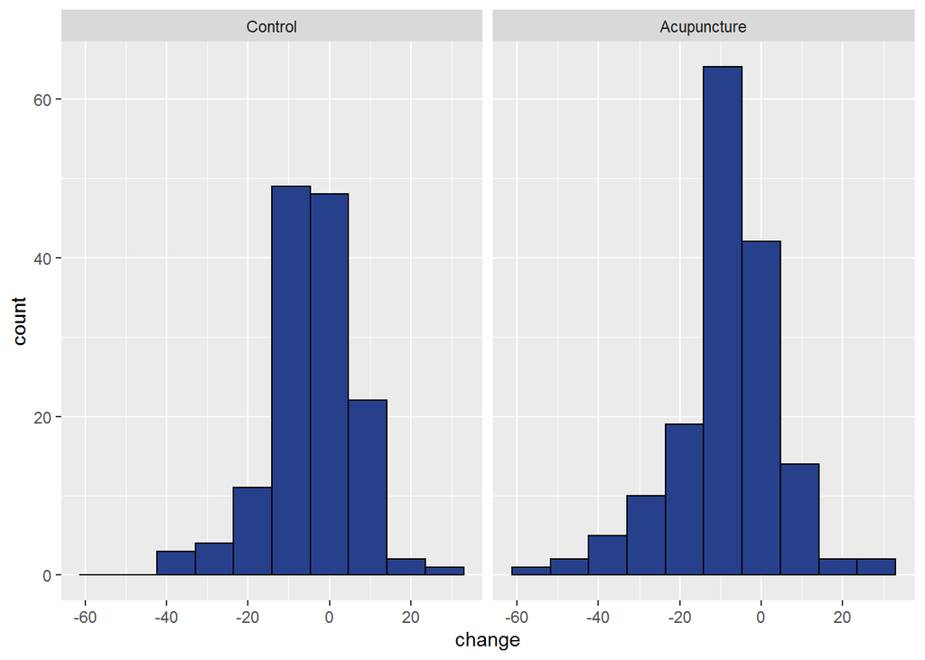

```r
labels <- c("0" = "Control", '1' = "Acupuncture") #factor labels

#histogram
p1 + aes(x = change) +
  facet_wrap(. ~ group, labeller = labeller(group = labels)) +
  geom_histogram(colour = "black", fill = "royalblue4", bins = 10)
```

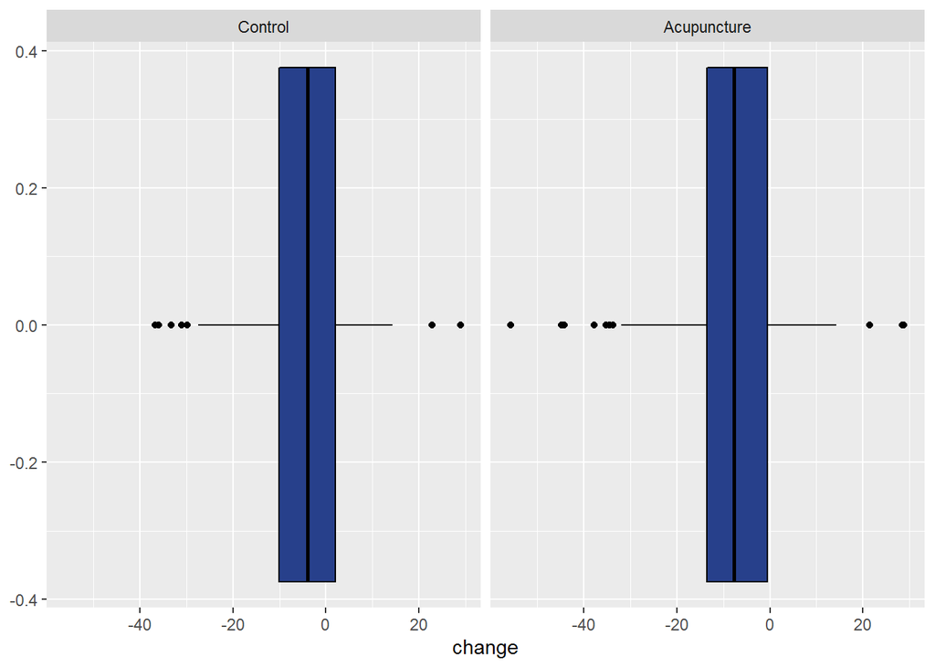

```r
#boxplot
p1 + aes(x = change) +
  facet_wrap(. ~ group, labeller = labeller(group = labels)) +
  geom_boxplot(fill = "royalblue4", colour = "black")
```

```r
#table
numSum <- psych::describeBy(no_missing[1:3], no_missing$group, fast = TRUE)
knitr::kable(numSum$`0`, caption = "Control"); knitr::kable(numSum$`1`, caption = "Acupuncture")
```

Control

|  | vars | n | mean | sd | min | max | range | se |
| --- | --- | --- | --- | --- | --- | --- | --- | --- |
| pk1 | 1 | 140 | 26.710714 | 16.77966 | 6.75 | 94.75 | 88.00 | 1.4181399 |
| pk5 | 2 | 140 | 22.343452 | 17.01089 | 0.25 | 87.25 | 87.00 | 1.4376828 |
| change | 3 | 140 | -4.367262 | 10.40231 | -36.75 | 29.00 | 65.75 | 0.8791555 |

Acupuncture

|  | vars | n | mean | sd | min | max | range | se |
| --- | --- | --- | --- | --- | --- | --- | --- | --- |
| pk1 | 1 | 161 | 24.576087 | 14.11828 | 8.75 | 74.00000 | 65.25000 | 1.112676 |
| pk5 | 2 | 161 | 16.246791 | 13.71828 | 0.00 | 73.73334 | 73.73334 | 1.081152 |
| change | 3 | 161 | -8.329296 | 12.70920 | -55.75 | 28.73334 | 84.48334 | 1.001626 |

## 2.2 Research question: what is the difference in the average change in headache severity score between groups?

We are trying to discern the difference in the average change between two categorical groups, those who have received acupuncture treatment and a control group. It is important to note that while originally the `change` variable was dependent for each observation in Part 1, we are now comparing the variable between two groups which are *not* dependent on each other. As such it is appropriate to perform a two-sample T Test.

### 2.2.1 F Test of Equal Variance

It is necessary to test for the variance in average change between the two groups in order to determine which type of two-sample T test to use.

The following conditons must be met: 1.Simple Random Sample 2. Two independent groups 3. Normally Distributed Outcomes

The first two conditons are already met, however we must evaluate the normality of the outcomes between groups. In this case the outcomes would be the `change` variable.

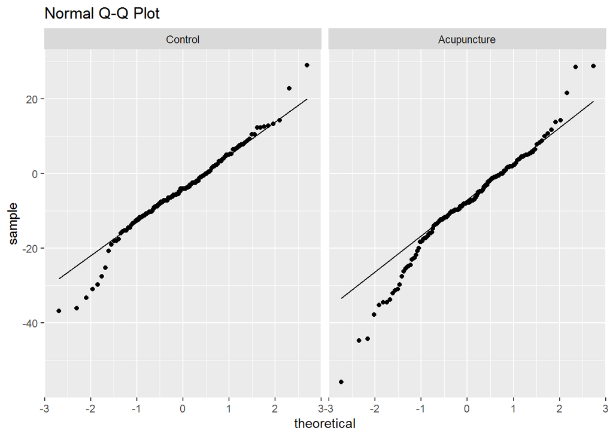

```r
# Q-Q Plot for Normality
labels <- c("0" = "Control", '1' = "Acupuncture")
p1 + aes(sample = change) +
 facet_wrap(. ~ group, labeller = labeller(group = labels)) +
stat_qq() + stat_qq_line() +
  ggtitle('Normal Q-Q Plot')
```

The above data suggests that the `change` variable is approximately normal in distribution, ignoring the outliers. Thus we will assume all conditions are satisfied and continue to perform F Test for Equality of Variance.

In this test $H_0: \frac{\sigma_{1}^2}{\sigma_{2}^2} = 1$ means the variance between the two groups are equal and $H_1: \frac{\sigma_{1}^2}{\sigma_{2}^2} \neq 1$ means that the variances between the two groups are unequal.

```r
# F test
var.test(change~ group, data=no_missing, alternative = "two.sided", conf.level=0.95)
```

```
##
##  F test to compare two variances
##
## data:  change by group
## F = 0.66992, num df = 139, denom df = 160, p-value = 0.0157
## alternative hypothesis: true ratio of variances is not equal to 1
## 95 percent confidence interval:
##  0.4860833 0.9267068
## sample estimates:
## ratio of variances
##          0.6699197
```

From the above we can see that the p-value is below the chosen significance level of 0.05, thus indicating that there is enough evidence to **reject the null hypothesis** that the variance between groups are even. Hence we conclude that we should perform a two-sample T test for unequal variance

### 2.2.2 Conditons

The conditions for the Two Sample T Test with Uneven Variance are as follows: 1. Simple Random Sample from Two Populations - Which we assume since this is a randomized clinical trial 2. Two independent groups - As explained above these two groups are unrelated 3. $N_1 > 30$ and $N_2 > 30$ or normally distributed outcomes in both populations - We checked this condition in the above F Test

### 2.2.3 Hypothesis

$H_0: \mu_1 - \mu_2 = 0$ which means that the population means between the two groups are even $H_1: \mu_1 - \mu_2 \neq 0$ which means that the population means between the two groups are not even

### 2.2.4 Two Sample T Test with Uneven Variance

```r
method3 <- t.test(no_missing$change~ no_missing$group, alternative ="two.sided", conf.level=0.95)
method3
```

```
##
##  Welch Two Sample t-test
##
## data:  no_missing$change by no_missing$group
## t = 2.9729, df = 297.94, p-value = 0.003191
## alternative hypothesis: true difference in means is not equal to 0
## 95 percent confidence interval:
##  1.339278 6.584790
## sample estimates:
## mean in group 0 mean in group 1
##       -4.367262       -8.329296
```

The above results give us Test Statistic of 2.9728716 which is not too large, but still indicates a meaningful difference between the expected null value of the difference of means between the two groups. The p-value indicates that we have a probability of 0.0031911 for getting the observed result under the assumption that the $H_0$ is true. This is far below our significance level of 0.05 and thus indicates we have sufficient evidence to **reject the null** hypothesis.

Our confidence interval is (1.3392781, 6.5847901) which doesn’t include the null value of 0 and thus agrees with the hypothesis test result, further supporting rejection of the null hypothesis.

### 2.2.5 Conclusion

In conclusion, the difference of means in change between the baseline headache severity and 1 year headache severity between the control and accupuncture group in the true population are real. The true population mean differences between these two time points within the control and acupuncture groups respectively are -4.3672619, -8.329296.